# Convenience Store Sales Analysis and Forecasting by Regression

```r
# install.packages('tidyverse')
# install.packages('jtools')
# install.packages('ggstance')
# install.packages('huxtable')
# install.packages('corrplot')
```

Load the tidyverse collection of packages.

```r
library(tidyverse)
```

```r
library(jtools)
library(corrplot)
```

Load the data

```r
trd <- readRDS('tecaRegressionData.rds')
```

## Simple Regressions

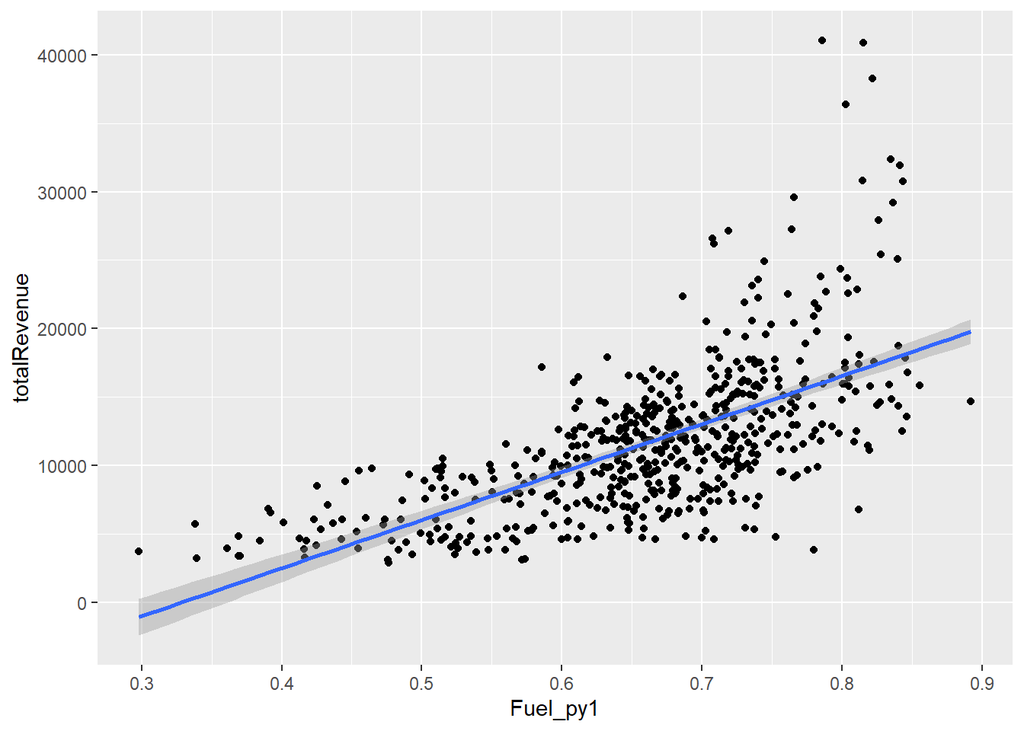

```r
ggplot(trd, aes(x = Fuel_py1, y = totalRevenue)) +
  geom_point() +
  stat_smooth(method = 'lm')
```

```r
lm1 <- lm(totalRevenue ~ Fuel_py1, data = trd)
lm2 <- lm(totalRevenue ~ Juicetonics_py1, data = trd)
export_summs(lm1, lm2)
```

|  | Model 1 | Model 2 |
| --- | --- | --- |
| (Intercept) | -11509.68 *** | 14295.79 *** |
|  | (1216.79) | (683.78) |
| Fuel_py1 | 35096.84 *** |  |
|  | (1815.14) |  |
| Juicetonics_py1 |  | -150275.47 *** |
|  |  | (37960.10) |
| N | 564 | 564 |
| R2 | 0.40 | 0.03 |
| *** p < 0.001; ** p < 0.01; * p < 0.05. |  |  |

The table indicates the key takeaways from both linear models:  
* Coefficient estimates  
* For model 1, the coefficient estimate is -11,509.68 for the intercept and is 35,096.84 for Fuel_py1.  
* For model 2, the coefficient estimate is 14,295.79 for the intercept and is -150,275.47 for Juicetonics_py1. * The standard errors are in parentheses below these coefficient estimates.  
* N stands for number of observations, and they are both based on 564 observations.  
* R2 is the R-squared, which is much larger for model 1, 40%, than for model 2, 3%. This means that model 1 explains more variation in totalRevenue than model 2, and is better for making predictions.

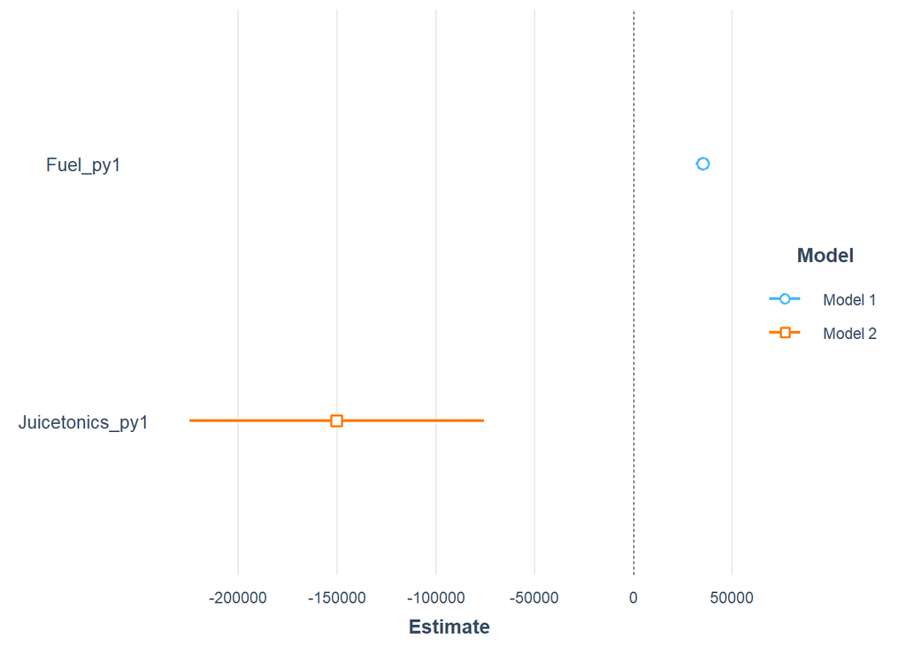

```r
plot_summs(lm1, lm2)
```

This visualization clearly shows that the coefficient on Fuel_py1 from model 1 is positive, and has a much smaller standard error relative to the negative coefficient on Juicetonics_py1 from model 2.

## Multiple Regression of totalRevenue on Fuel_py1 and Juicetonics_py1

```r
lm3 <- lm(totalRevenue ~ Fuel_py1 + Juicetonics_py1, data = trd)
export_summs(lm1, lm2, lm3)
```

|  | Model 1 | Model 2 | Model 3 |
| --- | --- | --- | --- |
| (Intercept) | -11509.68 *** | 14295.79 *** | -16855.87 *** |
|  | (1216.79) | (683.78) | (1680.95) |
| Fuel_py1 | 35096.84 *** |  | 39333.35 *** |
|  | (1815.14) |  | (2014.95) |
| Juicetonics_py1 |  | -150275.47 *** | 149875.80 *** |
|  |  | (37960.10) | (33106.72) |
| N | 564 | 564 | 564 |
| R2 | 0.40 | 0.03 | 0.42 |
| *** p < 0.001; ** p < 0.01; * p < 0.05. |  |  |  |

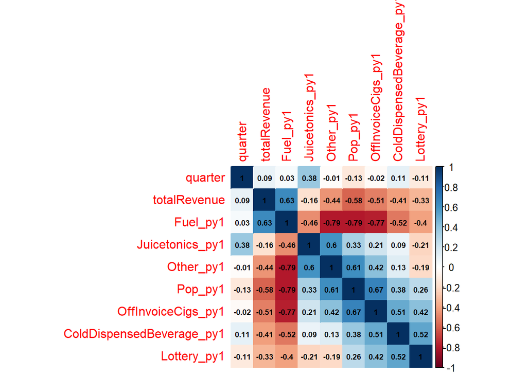

```r
ctrd <- cor(trd %>% select(where(is.numeric)))
corrplot(ctrd
         , method = 'color' # I also like pie and ellipse
         , order = 'hclust' # Orders the variables so that ones that behave similarly are placed next to each other
         , addCoef.col = 'black'
         , number.cex = .6 # Lower values decrease the size of the numbers in the cells
         )
```

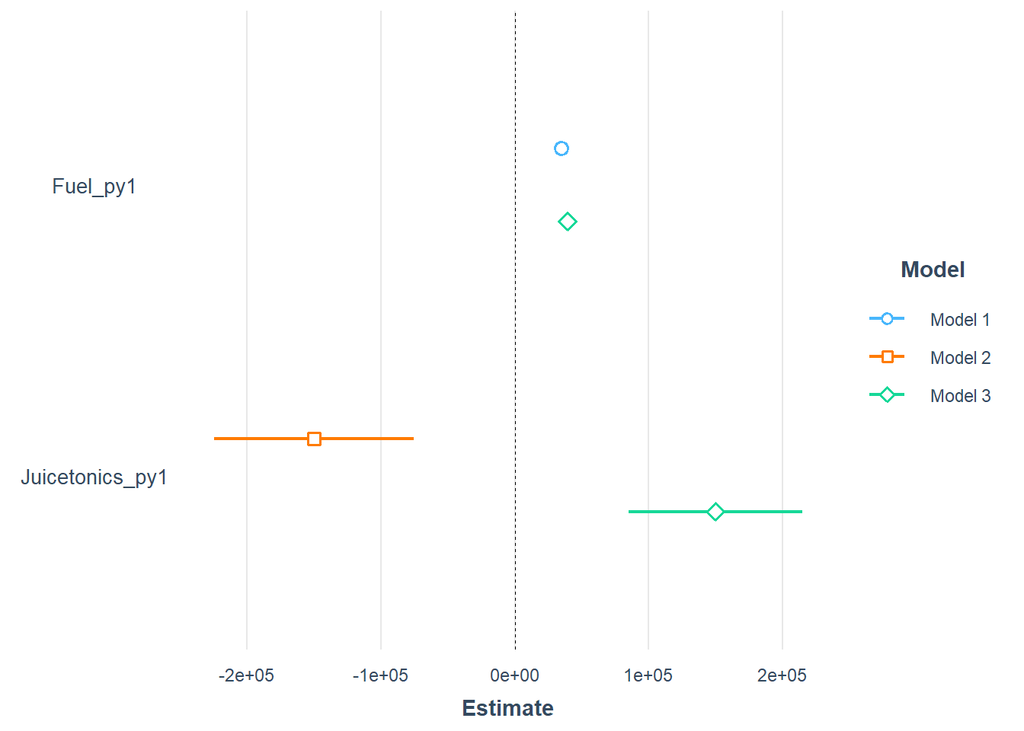

```r
plot_summs(lm1, lm2, lm3)
```

## Predictions

```r
lm4 = lm(totalRevenue ~ Fuel_py1 + Juicetonics_py1 + ColdDispensedBeverage_py1 + Lottery_py1, data = trd)
summary(lm4)
```

```
##
## Call:
## lm(formula = totalRevenue ~ Fuel_py1 + Juicetonics_py1 + ColdDispensedBeverage_py1 +
##     Lottery_py1, data = trd)
##
## Residuals:
##      Min       1Q   Median       3Q      Max
## -11128.2  -2566.3   -312.4   1855.2  25791.4
##
## Coefficients:
##                           Estimate Std. Error t value Pr(>|t|)
## (Intercept)                 -14330       2434  -5.886 6.82e-09 ***
## Fuel_py1                     36903       2610  14.140  < 2e-16 ***
## Juicetonics_py1             140171      37908   3.698 0.000239 ***
## ColdDispensedBeverage_py1   -60632      29829  -2.033 0.042558 *
## Lottery_py1                   1582       5963   0.265 0.790877
## ---
## Signif. codes:  0 '***' 0.001 '**' 0.01 '*' 0.05 '.' 0.1 ' ' 1
##
## Residual standard error: 4261 on 559 degrees of freedom
## Multiple R-squared:  0.4251, Adjusted R-squared:  0.421
## F-statistic: 103.4 on 4 and 559 DF,  p-value: < 2.2e-16
```

## Parsimony

```r
lm5 = lm(totalRevenue ~ Fuel_py1 + Juicetonics_py1 + ColdDispensedBeverage_py1, data = trd)
summary(lm5)
```

```
##
## Call:
## lm(formula = totalRevenue ~ Fuel_py1 + Juicetonics_py1 + ColdDispensedBeverage_py1,
##     data = trd)
##
## Residuals:
##      Min       1Q   Median       3Q      Max
## -11085.6  -2541.9   -333.1   1844.3  25796.8
##
## Coefficients:
##                           Estimate Std. Error t value Pr(>|t|)
## (Intercept)                 -14033       2159  -6.499 1.79e-10 ***
## Fuel_py1                     36629       2395  15.293  < 2e-16 ***
## Juicetonics_py1             135591      33721   4.021 6.59e-05 ***
## ColdDispensedBeverage_py1   -57848      27898  -2.074   0.0386 *
## ---
## Signif. codes:  0 '***' 0.001 '**' 0.01 '*' 0.05 '.' 0.1 ' ' 1
##
## Residual standard error: 4257 on 560 degrees of freedom
## Multiple R-squared:  0.4251, Adjusted R-squared:  0.422
## F-statistic:   138 on 3 and 560 DF,  p-value: < 2.2e-16
```

In this case, the adjusted R-squared even increased slightly.

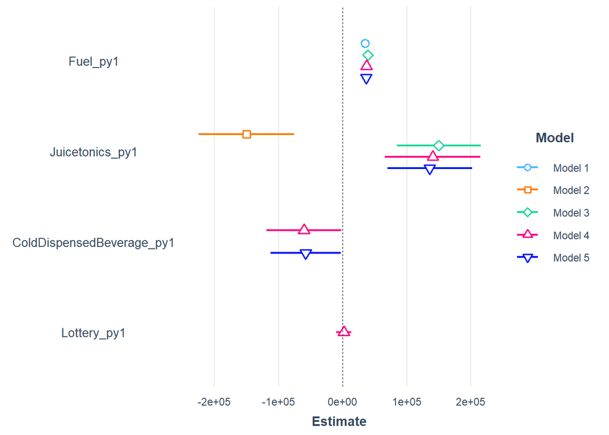

```r
plot_summs(lm1, lm2, lm3, lm4, lm5)
```